# Pre-processing

Julia Schwarz

28/10/2021

## Data File

Raw data file with all 1-17 adults + 1-17 children, no data removed except empty responses. 4285 observations.

## Participant screening

We will exclude participants reporting low commitment to the task, any major misunderstandings of the instructions, or significant technical problems (e.g. with the experiment display), and those who do not match our recruitment criteria despite pre-screening (cf. Data collection procedures).

Excluded:

We will exclude participants with an error rate above 20% (?) (24 or more out of 120 trials). After excluding participants 4030 data points left.

Participants with error rate above 20%: NONE Participants not meeting requirements: 1) Dyslexia: 210725_a180, (210725_a135; not in set), (210725_c142; not in set), (210725_c97; not in set) also c135 for now (relativey high N of error/large latencies; inspect in more detail)

## Exclude training trials

8 training trials per participant excluded. Remaining data = 3785.

```r
data <- subset(data, data$ITEM != '101L')
data <- subset(data, data$ITEM != '48L')
data <- subset(data, data$ITEM != '44L')
data <- subset(data, data$ITEM != '45H')
data <- subset(data, data$ITEM != '13H')
data <- subset(data, data$ITEM != '102L')
data <- subset(data, data$ITEM != '55H')
data <- subset(data, data$ITEM != '52H')
```

## Exclude incorrect trials

Incorrect and problematic trials were removed (N=164, 4.3%). Remaining data = 3621.

```r
data <- subset(data, data$ACC != 0)
3785-3621
```

```
## [1] 164
```

```r
164/3785
```

```
## [1] 0.04332893
```

## Items and trials (exclude items w high error rate)

Target words with an error rate of 40% or higher (cf. Crepaldi et al. 2016) will be removed from the analysis.

Items w 40% error rate or higher: NONE (?)

[[In addition, we might remove all trials where the target was ambiguous (charity meal, knob, a net); for now, none removed]].

## Inspect data and remove unnatural responses

After this cleaning process, reaction times will be inspected with histograms, with boxplots, and by Participant with qqplot. Data remaining: 3606.

```
## [1] 15
```

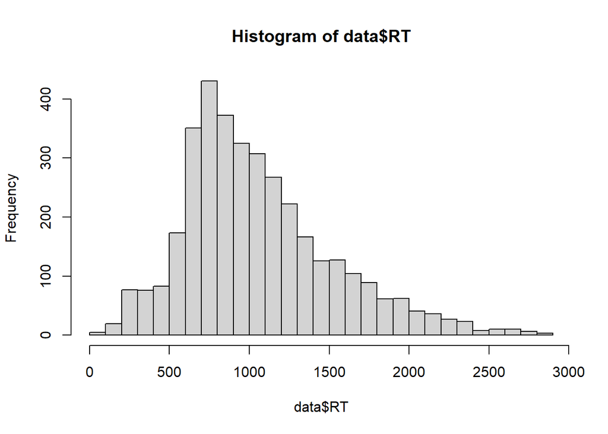

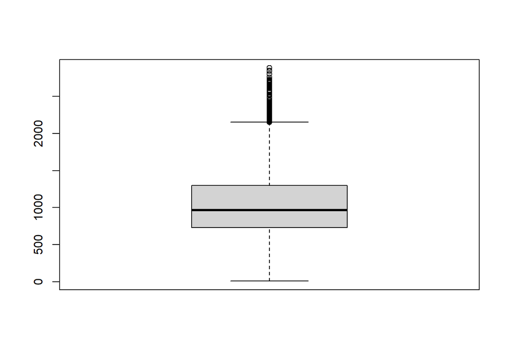

```
## [1] 0.8570337
```

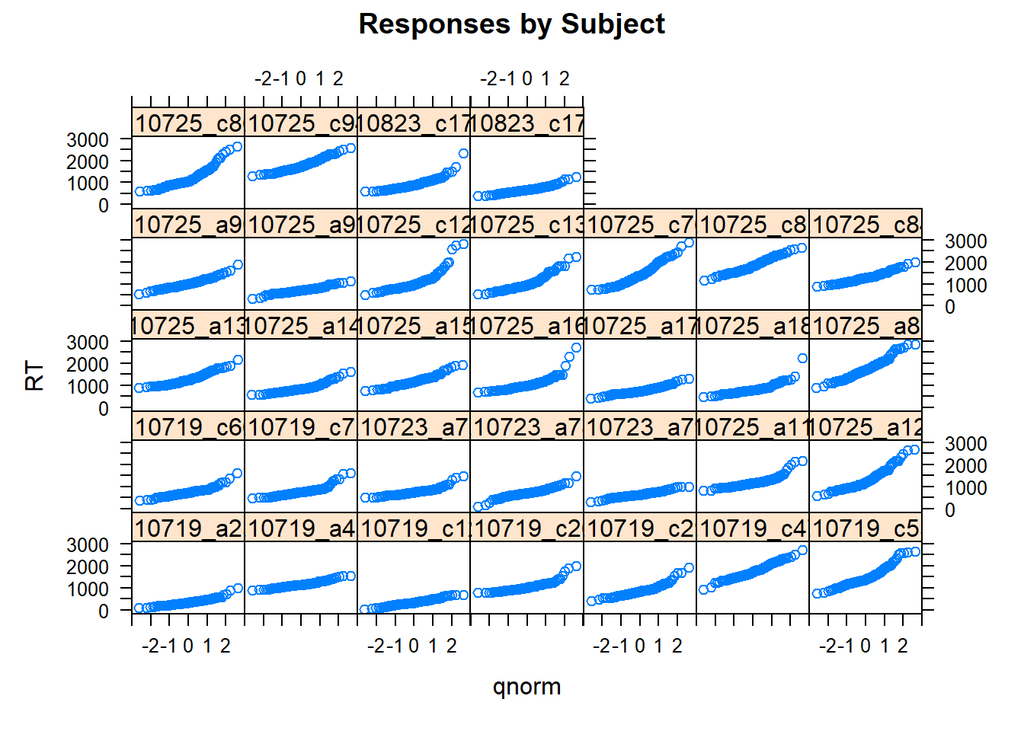

## Transform reaction times and remove outliers

The data were found to be positively skewed. Therefore we tested common transformations (actually only tested log so far) and chose the one with the best fit/but found no satisfactory improvement. Outliers three standard deviations from the mean per participant were removed.

Data remaining: 3560.

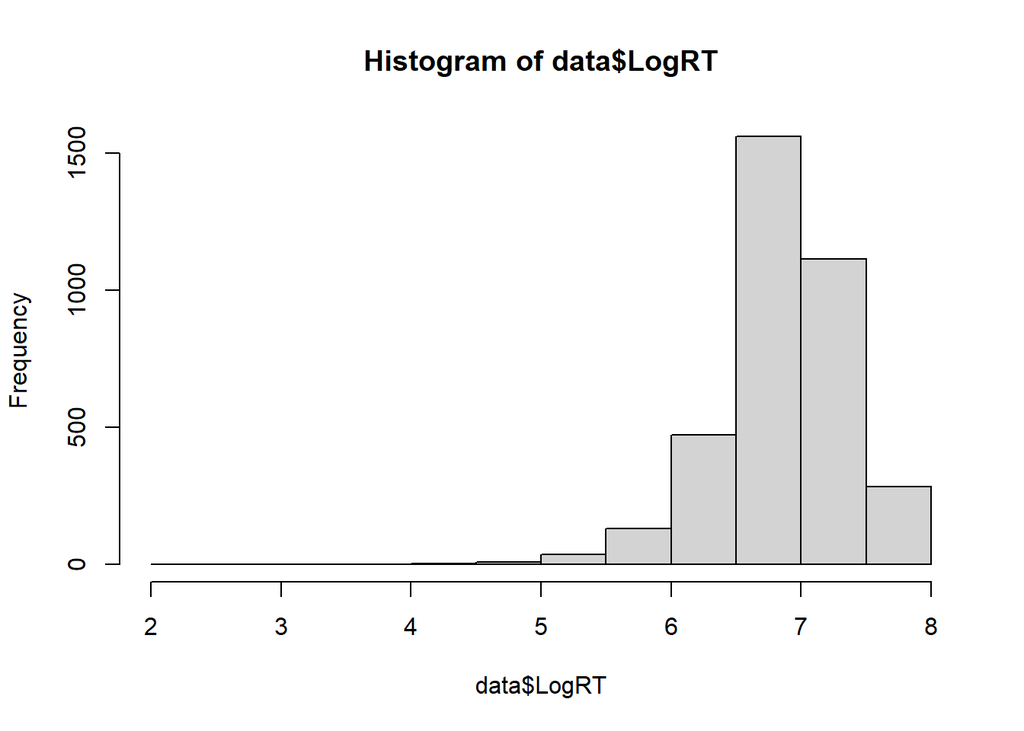

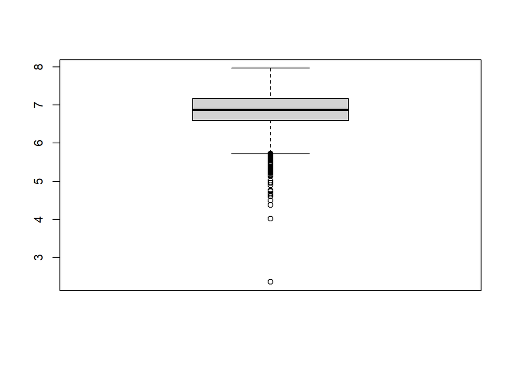

```
## [1] -0.961036
```

```
## [1] 0.8269577
```

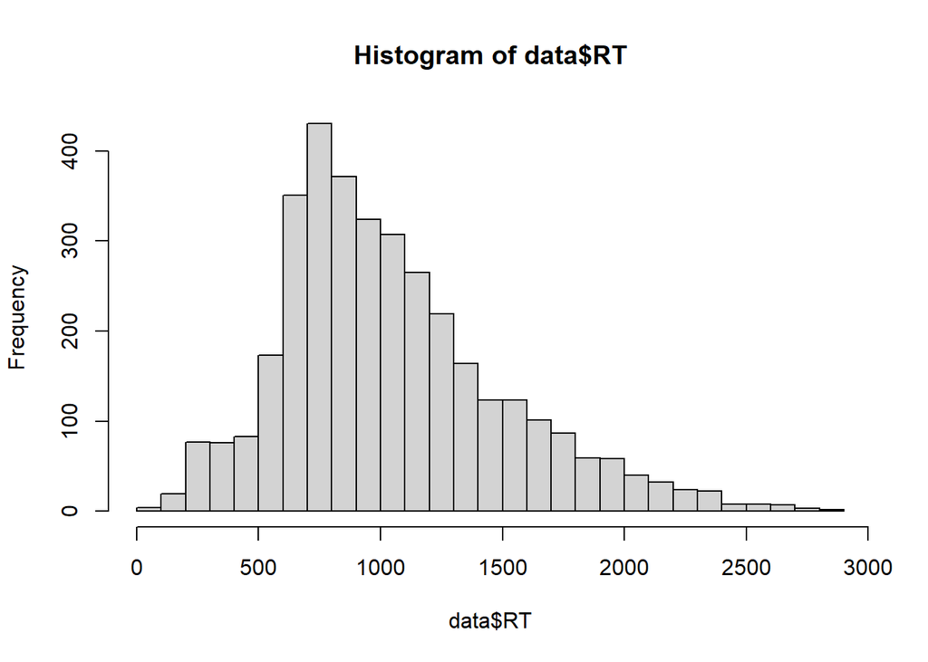

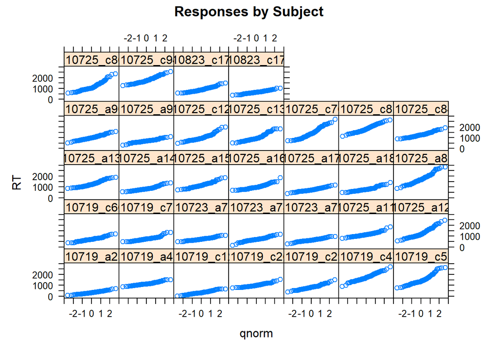

## Save cleaned data sheet

```r
write.table(data, "211029_subset_data_cleaned.txt", sep="\t", row.names=FALSE)
```